# Confidence Intervals Intro to OLS Regression POLS 3316: Statistics for Political Scientists

Tom Hanna

2023-11-12

## Confidence Intervals

- Review $X^2$ and t-test
- General hypothesis testing: scores and critical values
- Confidence intervals

## $X^2$ and t-test

- Note on formulas: Numbers in numerator or denominator of a fraction all get solved together as if in parentheses. PEMDAS is shorthand, but the P should really be G for “grouping symbols” and includes: parentheses ( ), brackets [ ], braces { }, and even fraction bars.

## Terms

- null hypothesis
- alternative hypothesis
- critical value (cutoff point)
- critical value is found using degrees of freedom and desired probability or alpha. (In z-scores, only probability is needed.)
- probability or p - confidence level

## Test Scores and Critical Values

- if the test score is greater than the critical value, reject the null
- The critical value is minimum
- Above that value, the probability that the null hypothesis is true is equal to or less than the target so we reject
- This all leads to confidence intervals

# Confidence intervals

## What is a confidence interval?

- Range where we could expect to find the true measurement based on the probability level we specify if we had the full population data instead of just the sample.
- Range where we expect to find the true population parameter given the sample statistic
- If we say the 95% confidence interval of the mean is from 45 to 55, it means we are 95% certain that the true population mean lies somewhere in that range.

## Getting the confidence interval

- The confidence intervals are based on the thing we actually measured, the probability level, and the distribution.
- If we know the population parameters (especially standard deviation) we can create simple CI using 68-95-99 rule or accurate CI using z-scores
- For small samples or uncertain population standard deviation we use appropriate distributions, such as Student’s t, to adjust for both these uncertainties

## Using t-scores to find confidence intervals

- For small samples or uncertain population standard deviation we use t-scores to adjust for these uncertainties

  ```
            - If we wanted to get a 95% confidence interval with 68-95-99, we would look for a value 2 standard deviations either side of the statistic we want to find a CI for
            - With t-test scores we divide the standard deviation by the square root of sample size and multiply times a t-table critical value instead.
            - We can get the critical value using the qt() function in R as in the examples
  ```

## Using t-scores to find confidence intervals

- $CI_\mu$ Confidence interval of the population mean
- $CI_\mu$ = $\bar{x} \pm t \frac{\sigma_{s}}{\sqrt{n}}$

Where:

- $\bar{x}$ = Sample mean
- $\mu$ = Population mean
- $\sigma_{s}$ = sample standard deviation
- n = sample size

## What about the normal distribution?

The 68-95-99 rule gives an oversimplified CI.

For normal distributions, the actual formula is:

## What about the normal distribution?

$CI_\mu$ Confidence interval of the population mean

$CI_\mu = \bar{x} \pm z \frac{\sigma}{\sqrt{n}}$

Where:

$\bar{x}$ Sample mean $\sigma$ population standard deviation $n$ is the sample size

- We can get the z-score from a z-table or from the qnorm() function in R

## Examples:

We’ll go through a couple of example computations, then I’ll provide you some sample R lab scripts (Quarto files).

## Examples:

- Sample mean: 50 = $\bar{x}$
- Sample standard deviation 5 = $\sigma_{s}$
- Sample size 18 = $n$
- Looking for a 95% confidence interval.

We need the t-score for a two-tailed test:

```r
qt(.025,17)
```

```
[1] -2.109816
```

## Examples:

```r
qt(.025,17)
```

```
[1] -2.109816
```

Then we can fill in the formula:

- $CI_\mu$ = $\bar{x} \pm t \frac{\sigma_{s}}{\sqrt{n}}$

```r
50 + c(-2.11, 2.11) * 5 / sqrt(18)
```

```
[1] 47.51334 52.48666
```

## Example 2:

Using the z-score:

- Sample mean: 50
- Population standard deviation: 5
- Sample size: 500
- We need a z-score for 95% (.025% above and .025% below):

```r
qnorm(.025)
```

```
[1] -1.959964
```

## Example 2

Then we apply the formula:

$CI_\mu = \bar{x} \pm z \frac{\sigma}{\sqrt{n}}$

```r
50 + c(-1.96, 1.96) * 5 / sqrt(500)
```

```
[1] 49.56173 50.43827
```

## Is this just about means?

NO!

The biggest use I see of confidence intervals is confidence intervals for **regression coefficients**

- $y = \alpha + \beta X + \epsilon$

If we find that the $\beta$ in the equation defining the relationship between our explanatory (x) and dependent (y) variables is 0.9, the confidence interval can tell us that it’s actually 95% likely that the true relationship is between 0.88 and 0.92.

Even better, we can graph it…

## Sample of graphing confidence interval in OLS

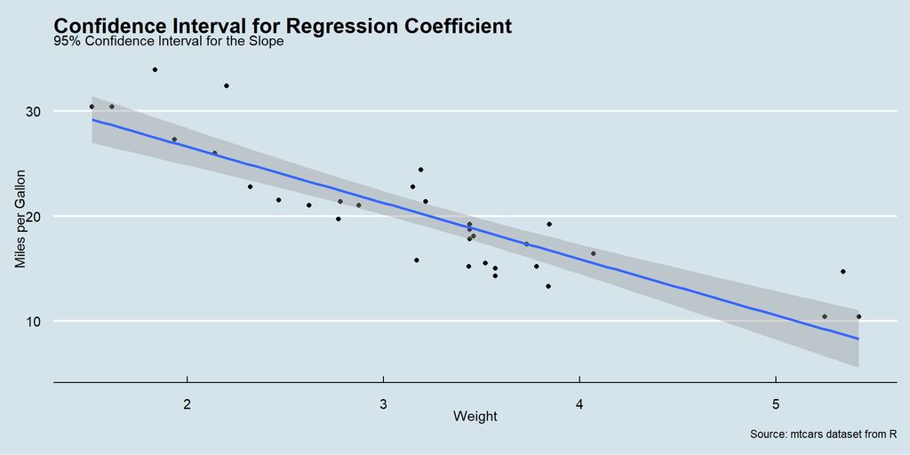

## Additional Resources for Confidence Intervals

https://www.statisticshowto.com/probability-and-statistics/confidence-interval/#WhatisCI

https://www.statisticshowto.com/probability-and-statistics/statistics-definitions/confidence-level/

https://www.statisticshowto.com/95-percent-confidence-interval/

## Authorship, License, Credits

- Author: Tom Hanna
- Website: [tomhanna.me](https://tom-hanna.org/)
- License: This work is licensed under a [Creative Commons Attribution-NonCommercial-ShareAlike 4.0 International License.](http://creativecommons.org/licenses/by-nc-sa/4.0/)

[figure not shown]

POLS3316, Fall 2023, Instructor: Tom Hanna